# Advanced Visualizations Lecture 05

## 3.5.0 Projecting our PCA onto 2 dimensions with `fviz_pca_ind`

Well, we appear to have successfully distilled our 200 gene set into 4 or so new principal components. We already had a sense that our 200 genes did a fairly good job in differentiating between our 5 immunocyte groups but can we capture just as much information using 4 new PCs?

Again, we’ll work with another `factoextra` function called `fviz_pca_ind()` which will help us to graph our individuals (aka our samples) based on the **new principal coordinates** we’ve created.

```r
# Graph our scaled PCA data.
fviz_pca_ind(rnaSeq_scaled.pca,
             repel = TRUE, # avoid overlapping text points
             labelsize = 5,
             axes = c(2,3)
            ) +

    theme(text = element_text(size=10)) # Make our text larger
```

[output not shown]

## 3.6.0 PCA can work on very large datasets too!

Well we started with a small example of our trimmed RNAseq dataset. Can we repeat or improve on our results using all 4000 genes as a source of data?

Remember our procedure:

1. Convert our data to a matrix, ensuring our observations are rows, our variables are columns.
2. Generate our PCA.
3. Make a scree plot to summarize the contributions of each new PC to overall variance.
4. Graph the data using (usually) the first 2 PCs. This can vary depending on *how much* variation is explained by those to PCs.

```r
# 1. Convert our data to a matrix. That's done so we'll just check it to be sure
str(t(rnaSeq.mx))
```

```
##  num [1:83, 1:4258] 215 273 229 222 236 ...
##  - attr(*, "dimnames")=List of 2
##   ..$ : chr [1:83] "B.fo.Sp#1.1" "B.fo.Sp#1.10" "B.fo.Sp#1.11" "B.fo.Sp#1.12" ...
##   ..$ : chr [1:4258] "0610030E20Rik" "1110059E24Rik" "1600012H06Rik" "1600014C10Rik" ...
```

```r
# 1. Build a PCA of our PHU data with scaling applied
rnaSeq_all_scaled.pca <- PCA(t(rnaSeq.mx),
                             scale.unit = TRUE, # What happens when we don't scale the data?
                             ncp = 10,
                             graph = TRUE)
```

[output not shown]

```r
# 2. Visualize the impact of our eigenvalues
fviz_eig(rnaSeq_all_scaled.pca, addlabels = TRUE) + theme(text = element_text(size=10))
```

[output not shown]

Finally let’s graph our data gain based on PC1/PC2

```r
rnaSeq_PCA.plot <-
# Graph our scaled PCA data.
fviz_pca_ind(rnaSeq_all_scaled.pca,
             repel = TRUE, # avoid overlapping text points
             labelsize = 5,
             axes = c(1,2)
            ) +

    theme(text = element_text(size=20)) # Make our text larger
```

[output not shown]

```r
rnaSeq_PCA.plot
```

[output not shown]

1. NK.Sp#1.17 is still grouped in with the majority of Tgd.Sp samples
2. NK.Sp#1.18 remains grouped in with the majority of MF.PC samples
3. Tgd.Sp.#1.8 is grouped a long way from any cluster
4. Now, however, we find that B.fo.Sp (B follicular cells) are grouped much further from the T.4.Nve (Naive CD4+) cells. This appears to be more in line with our expectations regarding their lineages.
5. In agreement with this, we now see our Tgd.Sp (gamma-delta T cells) are now more closely clustered with the Naive CD4+ cells. Both of these share a T lymphocyte lineage!

### 3.6.1 Principal component analysis is a good form of dimension reduction

While it may not be apparent, this form of analysis is a very solid and **deterministic** form of dimension reduction. Because we are working with pure algebraic transformation, we have an exact formula and set of values that can be used to:

1. Trace the transformation of each variable and observation onto each new principal component
2. Analyse the specific contributions of each variable to each new principal component

We will *always* be able to draw information from our PCA to help identify which variable(s) might be contributing highly to our new PCs and thus even identify which variables in the original data are more important to understanding the underlying structure of that data! No matter how many times we repeat this process on the same set of data, the results will **always** be the same!

The same cannot be said of some of our fancier friends like t-sne and umap. You’ll learn more about that in upcoming sections!

### 3.6.2 Start with as much data as you can and let PCA do the rest

What is our take-home message in comparing our smaller vs our larger dataset with something like PCA? Just as the title of the section implies, we can let PCA take the wheel in this case to help us group our data. Using feature elimination prior to PCA simply muddied the waters a bit by removing what could be key pieces of information from the data.

[output not shown]

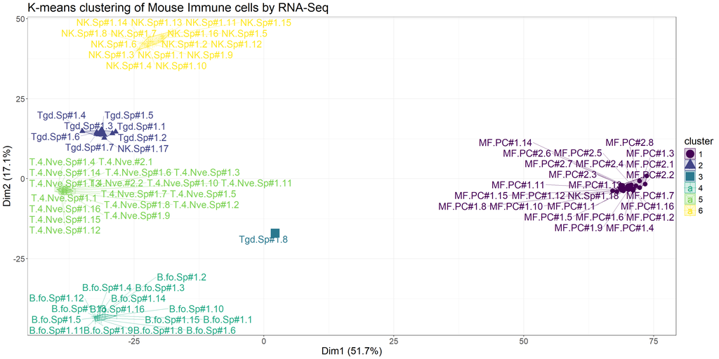

```r
# Plot both of our figures together
# fig.show="hold"; out.width="50%"; out.height = "50%"

rnaseq_kmeans.plot
rnaSeq_PCA.plot
```

**Why does our k-means clustering look like a PCA plot:** If you take a close look at our original `rnaseq_kmeans.plot`, you might notice the x- and y-axis are named Dim1(51.7%) and Dim2(17.1%). You may recall these are the exact percentage of variance explained in PC1 and PC2 of the eigenvalues in our principal component analysis. What’s going on here? In order to plot our original k-means cluster analysis, we provided our data matrix which was 83x4258. In order to project that 4258-dimension data onto a 2-dimensional plane, the `fviz_cluster()` function also needed to internally perform a PCA followed by picking the top 2 dimensions! Thus the point plotting was identical BUT the clustering was slightly different because we used *4258 features* in our first clustering vs *two features* in our second.

### 3.6.3 Use PCA to identify outlier samples

The other important message we should take from our results is that our PCA of the data helped to identify that two sets of samples within our data: NK.Sp#1.17 and NK.Sp#1.18 - both replicates from NK cell populations, were likely mislabeled. For whatever reason, perhaps at the stage of library preparation or by some mistake of the sorting process, these samples do not represent their labeled populations. Instead they highly correlate with other cell types in the experiment! A third sample, Tgd.Sp#1.8 also shows no real correlation with *any* of the populations. This could again be attributed to some kind of contamination or artifact of the sorting process.

### 3.6.4 Does PCA ever fail?

Yes. While we have shown a great example today of how PCA works, there are certainly exceptions to using this method. A major caveat to recall is that this is based on linear relationships being projected onto a linear subspace. Nonlinear relationships, heavy noise, poor correlation between variables and more can cause our PCA to fail. When that happens, we turn to other methods that use stochastic modeling, and local structure analysis to identify our clusters. You’ll learn more about some of those methods in section 4.0.0.

### 3.6.5 Was it worth it to use PCA?

From our estimations, the clustering choices look near identical between k-means and PCA. However, what we’ve really shown is that thousands of features can be distilled and combined into just 2 features! Could we do the same using just 2 features from our original dataset? No! So imagine transforming a much larger and feature-heavy dataset into a smaller number of features. From the data, we are also able to discern which of our original features may really contribute to each new principal component!

Something to consider the next time you’re working with a large data set!

## 3.7.0 Restart your R Session!

At this point, we’ve accumulated a lot of data in memory. We won’t need our previous data anymore so let’s restart R from the menu (Session>Restart R) and reload the libraries we’ll need.

```r
# Packages to help tidy our data
library(tidyverse)
library(readxl)
library(magrittr)

# Packages for the graphical analysis section
library(viridis)
library(RColorBrewer)

# Data projection packages
library(Rtsne)
library(umap)
```

# 4.0.0 Non-linear projection

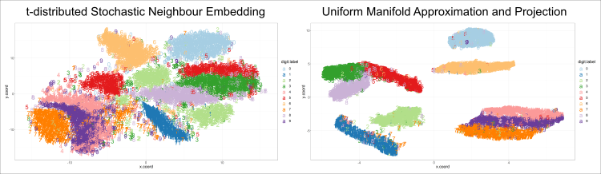

How do we identify trends or groups within deeply complex data in an unsupervised manner?

So we just spent most of our time trying to understand how to transform our sets based on the large amounts of variation in our data. There are some limitations we’ve discussed but in some cases, depending on your dataset size you may be interested in finding small, local similarities rather than the large variation that comes with PCA.

There are two popular projections we’ll discuss today but first let’s put together a more complex dataset based on some RNAseq data in `GSE150316_DeseqNormCounts_final.txt` and its companion file `2020.07.30.20165241-supp_tables.xlsx`

```r
# Read in our RNAseq data
tissue_data.df <- read.table(file = "./data/GSE150316_DeseqNormCounts_final.txt",
                             header = TRUE,
                             row.names = 1)
# Take a quick look at it
head(tissue_data.df)
```

|  | case1.lung1 | case1.lung2 | case1.lung3 | case1.lung4 | case1.heart1 | case2.lung1 | case2.lung2 | case2.jejunum1 | case2.lung3 | case2.heart1 | case3.lung1 | case3.heart1 | case3.lung2 | case4.lung1 | case4.heart1 | case4.liver1 | case4.lung2 | case4.kidney1 | case4.heart2 | case4.bowel1 | case5.lung1 | case5.lung2 | case5.lung3 | case5.lung4 | case5.fat1 | case5.lung5 | case5.skin1 | case5.bowel1 | case5.liver1 | … |
| --- | --- | --- | --- | --- | --- | --- | --- | --- | --- | --- | --- | --- | --- | --- | --- | --- | --- | --- | --- | --- | --- | --- | --- | --- | --- | --- | --- | --- | --- | --- |
| 5S_rRNA | 7.96319457 | 4.5713330 | 7.6071080 | 39.461459 | 225.083082 | 3.7434610 | 7.1978551 | 1.7137780 | 2.195275 | 11.33237 | 5.1500827 | 1.8377762 | 26.246271 | 84.8739533 | 198.239179 | 284.72206 | 53.1142 | 24.0586 | 163.489453 | 16.19045 | 17.8301501 | 204.14617 | 5.2150746 | 6.5310519 | 0.00000 | 4.7856618 | 1.8975379 | 4.2612716 | 261.001755 | … |
| 5_8S_rRNA | 1.01657803 | 0.0000000 | 1.0867297 | 10.961516 | 83.364104 | 1.4037979 | 1.6936130 | 0.0000000 | 2.927033 | 12.20409 | 3.5171296 | 2.7566644 | 8.075776 | 6.7899163 | 18.879922 | 23.72684 | 0.0000 | 0.0000 | 14.862678 | 10.95236 | 9.5673976 | 47.63411 | 2.8248321 | 3.4832277 | 0.00000 | 1.5952206 | 0.3795076 | 0.4734746 | 66.169459 | … |
| 7SK | 0.42357418 | 0.0000000 | 0.0000000 | 2.192303 | 2.778803 | 0.0000000 | 0.4234032 | 0.0000000 | 0.000000 | 0.00000 | 1.1305060 | 0.4594441 | 0.504736 | 2.5462186 | 9.439961 | 0.00000 | 0.0000 | 0.0000 | 0.000000 | 0.00000 | 0.8697634 | 0.00000 | 0.2172948 | 0.0000000 | 66.65604 | 0.0000000 | 1.8975379 | 0.4734746 | 0.000000 | … |
| A1BG | 0.16942967 | 0.0000000 | 0.5433649 | 0.000000 | 2.778803 | 0.0000000 | 0.8468065 | 0.0000000 | 0.000000 | 0.00000 | 0.1256118 | 0.0000000 | 0.000000 | 0.0000000 | 0.000000 | 23.72684 | 0.0000 | 0.0000 | 2.972536 | 0.00000 | 0.0000000 | 0.00000 | 0.6518843 | 0.4354035 | 0.00000 | 0.1994026 | 0.3795076 | 0.0000000 | 7.352162 | … |
| A1BG-AS1 | 0.16942967 | 0.9142666 | 0.5433649 | 8.769213 | 0.000000 | 0.4679326 | 0.8468065 | 0.0000000 | 1.829396 | 0.00000 | 0.6280589 | 0.0000000 | 2.018944 | 0.0000000 | 0.000000 | 0.00000 | 0.0000 | 0.0000 | 0.000000 | 0.00000 | 3.4790537 | 0.00000 | 1.0864739 | 0.8708069 | 0.00000 | 0.1994026 | 0.0000000 | 0.2367373 | 3.676081 | … |
| A1CF | 0.08471484 | 0.0000000 | 0.5433649 | 0.000000 | 36.124445 | 0.0000000 | 0.0000000 | 0.4284445 | 0.000000 | 0.00000 | 0.0000000 | 0.0000000 | 0.000000 | 0.8487395 | 0.000000 | 0.00000 | 0.0000 | 0.0000 | 0.000000 | 0.00000 | 0.0000000 | 0.00000 | 0.0000000 | 0.0000000 | 0.00000 | 0.0000000 | 0.0000000 | 0.0000000 | 102.930270 | … |

```r
dim(tissue_data.df)
```

```
## [1] 59090    88
```

```r
# Read in some additional patient data
patient_data.df <- read_excel("./data/2020.07.30.20165241-supp_tables.xlsx", sheet=2)

# Take a quick look at it
head(patient_data.df)
```

| Case No | Viral high vs. viral low* | Viral load (% positive tissue area by RNA ISH) | ISH hyaline membrane reactivity | RNA seq coverage | qRT PCR** | Keratin cells / mm2 | Napsin A cells / mm2 | CD1 63 cells/ mm2 | CD 3 Cells/ mm2 | CD 4 cells/ mm2 | CD8 cells/ mm2 | CD20 cells/ mm2 | CD123 cells/ mm2 | CD18 cells/ mm2 | CD56 cells/ mm2 | IDO1 cells/ mm2 | PD L1 cells/ mm2 |
| --- | --- | --- | --- | --- | --- | --- | --- | --- | --- | --- | --- | --- | --- | --- | --- | --- | --- |
| 1 | High | 81.2 | Present | 99.96 | Positive | 192 | 174 | 216 | 174 | 98 | 24 | 17 | 6 | 3 | 59 | 51 | 50 |
| 2 | Low | 0.5 | Absent | 9.4 | Positive | 335 | 429 | 1026 | 420 | 225 | 78 | 21 | 63 | 17 | 31 | 68 | 13 |
| 3 | Low | 2 | Absent | 1.27 | Positive | 663 | 474 | 855 | 956 | 354 | 212 | 51 | 14 | 3 | 25 | 52 | 1 |
| 4 | Low | <0.01 | Absent | 0.15 | Negative | 1045 | 680 | 723 | 290 | 152 | 39 | 23 | 31 | 7 | 54 | 27 | 1 |
| 5 | High | 18.5 | Present | 24.27 | Positive | 478 | 183 | 1010 | 386 | 203 | 65 | 12 | 4 | 2 | 20 | 28 | 10 |
| 6 | Low | 0.02 | Absent | 0.17 | Negative | 198 | 294 | 317 | 167 | 50 | 10 | 15 | 3 | 0.4 | 24 | 11 | 0.2 |

```r
dim(patient_data.df)
```

```
## [1] 24 18
```

### 4.0.1 Why can’t we use PCA on this dataset?

Before we attempt one of our non-linear projection methods, let’s see what happens if we use some of the methods we’ve spent all this time looking at. If one were to naively repeat our PCA steps on this tissue data using a k-means clustering based on 10 tissue groups in our data the following result would be produced..

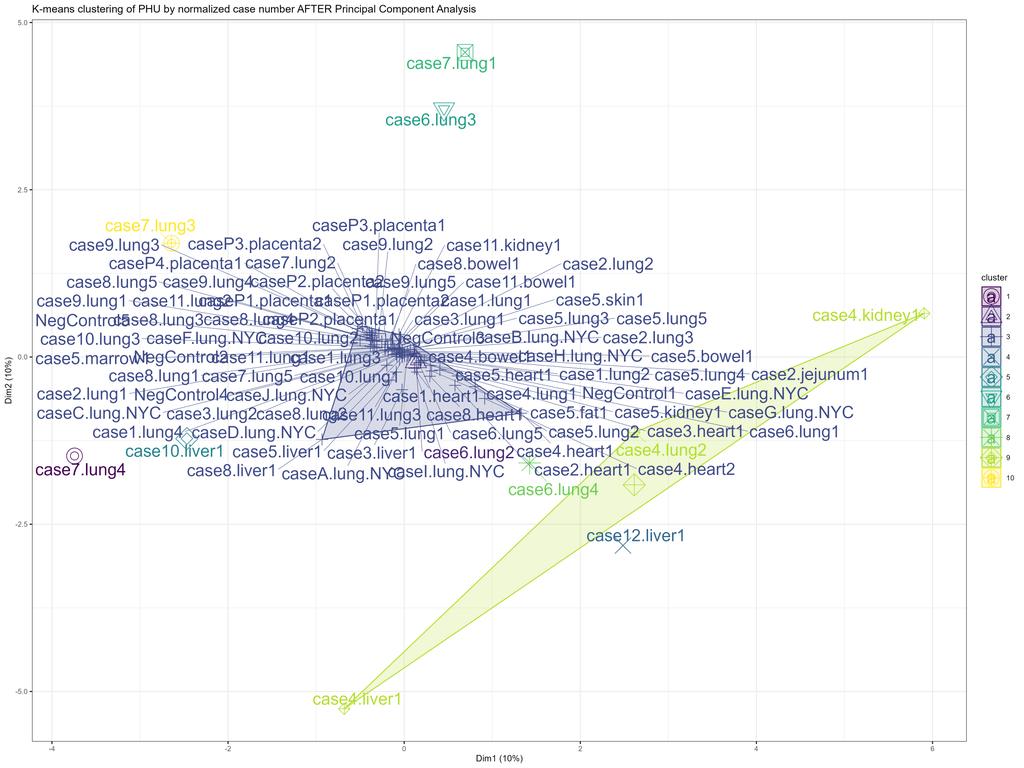

As we can see from the above plot, a majority of our samples from various tissue types fall into a single cluster. What’s more, as we’ll see, there is some structure in these samples as multiple samples come from the same patient. Sometimes even the same tissue! These relationships may have a large effect in the overall variation we see in the data, making it hard to distinguish between even tissue types. This is why we’ll turn to non-linear projection and see if it can help us out. Before that we’ll need to do some more wrangling…

### 4.0.2 Reformat our patient meta data

First let’s examine our `patient_data.df` which has 24 patient samples (aka cases) listed in total. These 24 cases relate back to `tissue_data.df` which have variables representing different combinations of case and tissue type and observations for some 59K transcripts.

At this point we want to reformat the column names in `patient_data.df` a bit before selecting for just the viral load and viral load percentage information located in the 2nd and 3rd column. We’ll hold onto this in `patient_viral_load.df` for later use.

```r
# Create a dataframe holding just the viral_load information for each patient
patient_viral_load.df <-
  patient_data.df %>%

  # Retain just the first 3 columns
  dplyr::select(1:3) %>%

  # Rename the 2nd and 3rd columns
  dplyr::rename(case_num = 1, viral_load = 2, viral_load_percent = 3)

head(patient_viral_load.df)
```

| case_num | viral_load | viral_load_percent |
| --- | --- | --- |
| 1 | High | 81.2 |
| 2 | Low | 0.5 |
| 3 | Low | 2 |
| 4 | Low | <0.01 |
| 5 | High | 18.5 |
| 6 | Low | 0.02 |